# R Notebook

```r
library(tidyverse)
library(janitor)
library(fastDummies)
library(GGally)
library(ggfortify)
library(mosaic)
library(mosaicData)
```

```r
library(readr)
housing_prices <- read_csv("4_homework/data/housing_prices.csv")
View(housing_prices)
```

```r
housing_prices%>%
  clean_names()
```

| longitude | latitude | housing_median_age | total_rooms | total_bedrooms | population | households | median_income | median_house_value | ocean_proximity |
| --- | --- | --- | --- | --- | --- | --- | --- | --- | --- |
| -122.23 | 37.88 | 41 | 880 | 129 | 322 | 126 | 8.3252 | 452600 | NEAR BAY |
| -122.22 | 37.86 | 21 | 7099 | 1106 | 2401 | 1138 | 8.3014 | 358500 | NEAR BAY |
| -122.24 | 37.85 | 52 | 1467 | 190 | 496 | 177 | 7.2574 | 352100 | NEAR BAY |
| -122.25 | 37.85 | 52 | 1274 | 235 | 558 | 219 | 5.6431 | 341300 | NEAR BAY |
| -122.25 | 37.85 | 52 | 1627 | 280 | 565 | 259 | 3.8462 | 342200 | NEAR BAY |
| -122.25 | 37.85 | 52 | 919 | 213 | 413 | 193 | 4.0368 | 269700 | NEAR BAY |
| -122.25 | 37.84 | 52 | 2535 | 489 | 1094 | 514 | 3.6591 | 299200 | NEAR BAY |
| -122.25 | 37.84 | 52 | 3104 | 687 | 1157 | 647 | 3.1200 | 241400 | NEAR BAY |
| -122.26 | 37.84 | 42 | 2555 | 665 | 1206 | 595 | 2.0804 | 226700 | NEAR BAY |
| -122.25 | 37.84 | 52 | 3549 | 707 | 1551 | 714 | 3.6912 | 261100 | NEAR BAY |

[output cut: 990 more lines]

```r
glimpse(housing_prices)
```

```
Rows: 19,675
Columns: 10
$ longitude          <dbl> -122.23, -122.22, -122.24, -122.25, -122.25, -122.25,…
$ latitude           <dbl> 37.88, 37.86, 37.85, 37.85, 37.85, 37.85, 37.84, 37.8…
$ housing_median_age <dbl> 41, 21, 52, 52, 52, 52, 52, 52, 42, 52, 52, 52, 52, 5…
$ total_rooms        <dbl> 880, 7099, 1467, 1274, 1627, 919, 2535, 3104, 2555, 3…
$ total_bedrooms     <dbl> 129, 1106, 190, 235, 280, 213, 489, 687, 665, 707, 43…
$ population         <dbl> 322, 2401, 496, 558, 565, 413, 1094, 1157, 1206, 1551…
$ households         <dbl> 126, 1138, 177, 219, 259, 193, 514, 647, 595, 714, 40…
$ median_income      <dbl> 8.3252, 8.3014, 7.2574, 5.6431, 3.8462, 4.0368, 3.659…
$ median_house_value <dbl> 452600, 358500, 352100, 341300, 342200, 269700, 29920…
$ ocean_proximity    <chr> "NEAR BAY", "NEAR BAY", "NEAR BAY", "NEAR BAY", "NEAR…
```

#1 We expect the total_rooms of houses to be strongly correlated with total_bedrooms. Use ggpairs() to investigate correlations between these two variables.

## Firstly looked at developing some other bedrooms

```r
bear_in_house <-housing_prices %>%
  mutate(bedrooms_per_house = total_bedrooms/households,
         rooms_per_house = total_rooms/households,
         people_per_house = population/households,
         bedrooms_per_house = total_bedrooms/population,
         rooms_per_house = total_rooms/population,
         bedrooms_per_house = total_bedrooms / total_rooms,
         non_bedrooms_per_house = rooms_per_house- bedrooms_per_house)
```

```r
glimpse(bear_in_house)
```

```
Rows: 19,675
Columns: 14
$ longitude              <dbl> -122.23, -122.22, -122.24, -122.25, -122.25, -122…
$ latitude               <dbl> 37.88, 37.86, 37.85, 37.85, 37.85, 37.85, 37.84, …
$ housing_median_age     <dbl> 41, 21, 52, 52, 52, 52, 52, 52, 42, 52, 52, 52, 5…
$ total_rooms            <dbl> 880, 7099, 1467, 1274, 1627, 919, 2535, 3104, 255…
$ total_bedrooms         <dbl> 129, 1106, 190, 235, 280, 213, 489, 687, 665, 707…
$ population             <dbl> 322, 2401, 496, 558, 565, 413, 1094, 1157, 1206, …
$ households             <dbl> 126, 1138, 177, 219, 259, 193, 514, 647, 595, 714…
$ median_income          <dbl> 8.3252, 8.3014, 7.2574, 5.6431, 3.8462, 4.0368, 3…
$ median_house_value     <dbl> 452600, 358500, 352100, 341300, 342200, 269700, 2…
$ ocean_proximity        <chr> "NEAR BAY", "NEAR BAY", "NEAR BAY", "NEAR BAY", "…
$ bedrooms_per_house     <dbl> 0.1465909, 0.1557966, 0.1295160, 0.1844584, 0.172…
$ rooms_per_house        <dbl> 2.732919, 2.956685, 2.957661, 2.283154, 2.879646,…
$ people_per_house       <dbl> 2.555556, 2.109842, 2.802260, 2.547945, 2.181467,…
$ non_bedrooms_per_house <dbl> 2.586328, 2.800888, 2.828145, 2.098696, 2.707550,…
```

```r
ggpairs1 <-bear_in_house%>%
  select(median_house_value,
         housing_median_age,
         ocean_proximity,
         median_income)%>%
  ggpairs()%>%
```

```r
ggpairs2 <-bear_in_house%>%
  select(median_house_value,
         total_rooms,
         rooms_per_house,
         total_bedrooms,
         bedrooms_per_house)%>%
ggpairs(ggpairs2)
```

```r
ggpairs3 <-bear_in_house%>%
  select(median_house_value,
         )
```

```r
bear_in_house%>%
  count(ocean_proximity)
```

| ocean_proximity | n |
| --- | --- |
| <1H OCEAN | 8604 |
| INLAND | 6524 |
| ISLAND | 5 |
| NEAR BAY | 2096 |
| NEAR OCEAN | 2446 |

```r
bear_in_house%>%
  select(ocean_proximity, median_house_value)
```

| ocean_proximity | median_house_value |
| --- | --- |
| NEAR BAY | 452600 |
| NEAR BAY | 358500 |
| NEAR BAY | 352100 |
| NEAR BAY | 341300 |
| NEAR BAY | 342200 |
| NEAR BAY | 269700 |
| NEAR BAY | 299200 |
| NEAR BAY | 241400 |
| NEAR BAY | 226700 |
| NEAR BAY | 261100 |

[output cut: 990 more lines]

```r
NA
```

```r
rooms_bedrooms <- housing_prices %>%
  select(total_rooms, total_bedrooms)
```

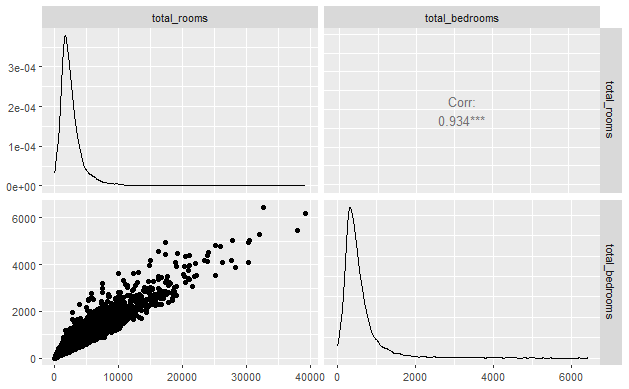

```r
library(GGally)
ggpairs(rooms_bedrooms) + theme_grey()
```

## strong correlation between the number of bedrooms and the number of rooms overall.

## correlations and coefficient - 1 - 0 - so anything close to 1 then strong correlation.

## coefficnet is a number that expresses a measurment of a particular quantity of a substance or object.

##So, we do find significant correlations. Let’s drop total_bedrooms from the dataset, and use only total_rooms going forward.

```r
housing_pricestrimmed <-housing_prices%>%
  select(-c (total_bedrooms))
```

```r
library(GGally)
ggpairs(housing_pricestrimmed) + theme_grey()
```

##That looks a mess - loads of blobs and not sure what it is showing.

We are interested in developing a regression model for the median_house_value of a house in terms of the possible predictor variables in the dataset.

Use ggpairs() to investigate correlations between median_house_value and the predictors (this may take a while to run, don’t worry, make coffee or something).

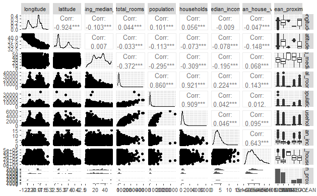

```r
ggpairs(housing_pricestrimmed)
```

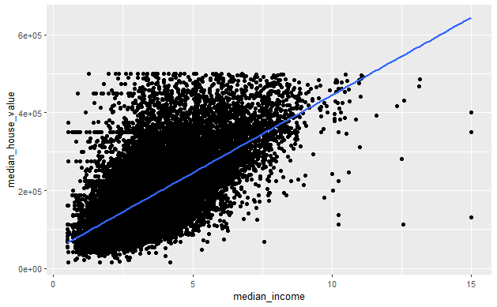

```r
housing_pricestrimmed %>%
  ggplot(aes(x = median_income, y = median_house_value)) +
  geom_point() +
  geom_smooth(method = "lm", se = FALSE)
```

##so do produce a number of plots to look at the predictable variable.

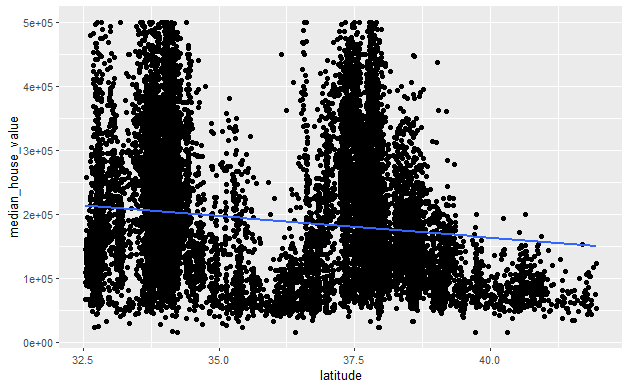

```r
housing_pricestrimmed %>%
  ggplot(aes(x = latitude, y = median_house_value)) +
  geom_point() +
  geom_smooth(method = "lm", se = FALSE)
```

##keep the Y axis constant (median house value) and then change the x axis.

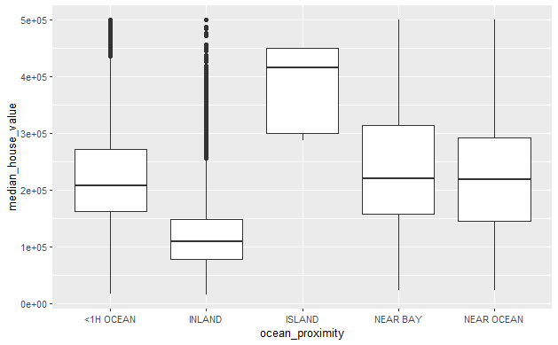

```r
housing_pricestrimmed%>%
  ggplot(aes(x = ocean_proximity, y = median_house_value)) +
  geom_boxplot()
```

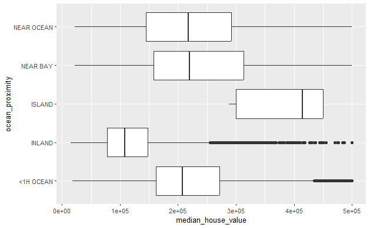

```r
housing_pricestrimmed %>%
  ggplot(aes(median_house_value,ocean_proximity)) +
  geom_boxplot()
```

```r
housing_pricestrimmed %>%
  distinct(ocean_proximity)
```

| ocean_proximity |
| --- |
| NEAR BAY |
| <1H OCEAN |
| INLAND |
| NEAR OCEAN |
| ISLAND |

#4 dummy predictors

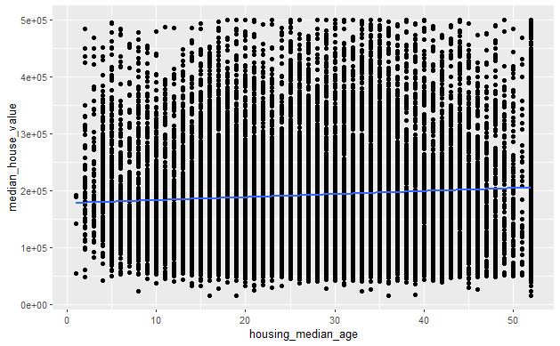

```r
housing_pricestrimmed %>%
  ggplot(aes(x = housing_median_age, y = median_house_value)) +
  geom_point() +
  geom_smooth(method = "lm", se = FALSE)
```

```r
mod1 <- lm(median_house_value ~ median_income,
           data = housing_pricestrimmed)

summary(mod1)
```

```
Call:
lm(formula = median_house_value ~ median_income, data = housing_pricestrimmed)

Residuals:
    Min      1Q  Median      3Q     Max
-513966  -51564  -13979   36549  403935

Coefficients:
              Estimate Std. Error t value Pr(>|t|)
(Intercept)    45457.0     1359.0   33.45   <2e-16 ***
median_income  39987.0      339.9  117.64   <2e-16 ***
---
Signif. codes:  0 ‘***’ 0.001 ‘**’ 0.01 ‘*’ 0.05 ‘.’ 0.1 ‘ ’ 1

Residual standard error: 74870 on 19673 degrees of freedom
Multiple R-squared:  0.4129,    Adjusted R-squared:  0.4129
F-statistic: 1.384e+04 on 1 and 19673 DF,  p-value: < 2.2e-16
```

[figure not shown]

```r
autoplot(mod1)
```

```r
mod2<- lm(median_house_value ~ ocean_proximity,
           data = housing_pricestrimmed)

summary(mod2)
```

```
Call:
lm(formula = median_house_value ~ ocean_proximity, data = housing_pricestrimmed)

Residuals:
    Min      1Q  Median      3Q     Max
-214426  -57783  -15113   41347  376747

Coefficients:
                           Estimate Std. Error t value Pr(>|t|)
(Intercept)                224013.2      911.7 245.717  < 2e-16 ***
ocean_proximityINLAND     -100760.6     1388.3 -72.580  < 2e-16 ***
ocean_proximityISLAND      156426.8    37829.4   4.135 3.56e-05 ***
ocean_proximityNEAR BAY     12912.4     2059.8   6.269 3.72e-10 ***
ocean_proximityNEAR OCEAN    3703.6     1937.7   1.911    0.056 .
---
Signif. codes:  0 ‘***’ 0.001 ‘**’ 0.01 ‘*’ 0.05 ‘.’ 0.1 ‘ ’ 1

Residual standard error: 84560 on 19670 degrees of freedom
Multiple R-squared:  0.2511,    Adjusted R-squared:  0.251
F-statistic:  1649 on 4 and 19670 DF,  p-value: < 2.2e-16
```

```r
mod3<- lm(median_income ~ ocean_proximity,
           data = housing_pricestrimmed)

summary(mod3)
```

```
Call:
lm(formula = median_income ~ ocean_proximity, data = housing_pricestrimmed)

Residuals:
    Min      1Q  Median      3Q     Max
-3.4990 -1.0950 -0.2073  0.8786 11.0012

Coefficients:
                          Estimate Std. Error t value Pr(>|t|)
(Intercept)                3.99886    0.01648 242.654  < 2e-16 ***
ocean_proximityINLAND     -0.81004    0.02509 -32.279  < 2e-16 ***
ocean_proximityISLAND     -1.25444    0.68382  -1.834  0.06660 .
ocean_proximityNEAR BAY   -0.10585    0.03723  -2.843  0.00448 **
ocean_proximityNEAR OCEAN -0.33741    0.03503  -9.633  < 2e-16 ***
---
Signif. codes:  0 ‘***’ 0.001 ‘**’ 0.01 ‘*’ 0.05 ‘.’ 0.1 ‘ ’ 1

Residual standard error: 1.529 on 19670 degrees of freedom
Multiple R-squared:  0.05254,   Adjusted R-squared:  0.05235
F-statistic: 272.7 on 4 and 19670 DF,  p-value: < 2.2e-16
```

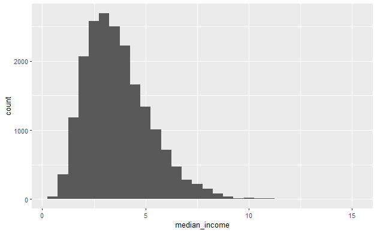

```r
ggplot(housing_pricestrimmed, aes (x = median_income))+
  geom_histogram()
```